# Descriptive Statistics

# Descriptive Statistics

## Using `describe()`

Now let’s try to get some descriptive statistics for our example data set. One of the quickest ways to get a good variety of summary statistics is to use the `describe()` function from the {psych} package. As you can see from the output below, if you have a lot of variables it can be hard to read the output, so I usually put it inside the `View()` function to see it inside a new tab within RStudio.

For information on using `View()`, check out the “Tibble” section of the “Working with Tibbles” primer at https://rstudio.cloud/learn/primers/2.1

```r
# Example of what you would type in RStudio.
# These results are not shown in this exercise.
View(describe(data_sugar))
```

```r
# The results below are the result of this function.
describe(data_sugar)
```

```
##                                      vars   n   mean
## id                                      1 623 312.00
## IV_condition*                           2 623   2.49
## IV_service_dummy                        3 623   0.50
## IV_portion_dummy                        4 623   0.49
## IV_service_dummy_by_IV_portion_dummy    5 623   0.24
## DV_order_at_all                         6 623   0.58
## DV_order_large                          7 362   0.33
## DV_ounces_consumed                      8 623   9.32
## DV_calories_consumed                    9 623  69.33
## flavor                                 10 362   0.58
## sex*                                   11 623   1.55
## age                                    12 610  24.11
## ethnicity                              13 621   3.67
## comprehension_check                    14 319   3.30
## failed_comprehension_check             15 623   0.07
##                                          sd median
## id                                   179.99 312.00
## IV_condition*                          1.11   3.00
## IV_service_dummy                       0.50   1.00
## IV_portion_dummy                       0.50   0.00
## IV_service_dummy_by_IV_portion_dummy   0.43   0.00
## DV_order_at_all                        0.49   1.00
## DV_order_large                         0.47   0.00
## DV_ounces_consumed                     8.89  10.22
## DV_calories_consumed                  69.69  69.00
## flavor                                 0.49   1.00
## sex*                                   0.50   2.00
## age                                    5.72  22.00
## ethnicity                              1.28   4.00
## comprehension_check                    1.41   3.00
## failed_comprehension_check             0.26   0.00
##                                      trimmed    mad min
## id                                    312.00 231.29   1
## IV_condition*                           2.49   1.48   1
## IV_service_dummy                        0.50   0.00   0
## IV_portion_dummy                        0.49   0.00   0
## IV_service_dummy_by_IV_portion_dummy    0.18   0.00   0
## DV_order_at_all                         0.60   0.00   0
## DV_order_large                          0.29   0.00   0
```

[output cut: 25 more lines]

```
## id                                      -1.21 7.21
## IV_condition*                           -1.35 0.04
## IV_service_dummy                        -2.00 0.02
## IV_portion_dummy                        -2.00 0.02
## IV_service_dummy_by_IV_portion_dummy    -0.56 0.02
## DV_order_at_all                         -1.90 0.02
## DV_order_large                          -1.48 0.02
## DV_ounces_consumed                      -1.47 0.36
## DV_calories_consumed                    -0.92 2.79
## flavor                                  -1.90 0.03
## sex*                                    -1.96 0.02
## age                                     13.24 0.23
## ethnicity                                0.41 0.05
## comprehension_check                     -1.58 0.08
## failed_comprehension_check               8.88 0.01
```

If you want to compute descriptive statistics for a subset of your data set, try to use the `select()` function we used earlier alongside the piping operator, `%>%`. You can learn more about piping operator within the `%>%` section of the “Isolating Data with dplyr” primer at https://rstudio.cloud/learn/primers/2.2.

```r
# start with the full data set, and then ...
# select() the continuous variables you want, and then ...
# compute descriptive statistics, and then ...
# View() the results in RStudio.
data_sugar %>%
  select(age,
         DV_ounces_consumed,
         DV_calories_consumed) %>%
  describe() %>%
  View()
```

Here is a cleaned up peek at the summary generated using the `describe()` function. In the upper right corner is a small black arrow which lets you view the other columns in this summary data set.

|  | vars | n | mean | sd | median | trimmed | mad | min | max | range | skew | kurtosis | se |
| --- | --- | --- | --- | --- | --- | --- | --- | --- | --- | --- | --- | --- | --- |
| id | 1 | 623 | 312.000 | 179.989 | 312.00 | 312.000 | 231.286 | 1 | 623 | 622 | 0.000 | -1.206 | 7.211 |
| IV_condition* | 2 | 623 | 2.491 | 1.114 | 3.00 | 2.489 | 1.483 | 1 | 4 | 3 | 0.001 | -1.354 | 0.045 |
| IV_service_dummy | 3 | 623 | 0.501 | 0.500 | 1.00 | 0.501 | 0.000 | 0 | 1 | 1 | -0.003 | -2.003 | 0.020 |
| IV_portion_dummy | 4 | 623 | 0.490 | 0.500 | 0.00 | 0.487 | 0.000 | 0 | 1 | 1 | 0.042 | -2.001 | 0.020 |
| IV_service_dummy_by_IV_portion_dummy | 5 | 623 | 0.242 | 0.429 | 0.00 | 0.178 | 0.000 | 0 | 1 | 1 | 1.199 | -0.562 | 0.017 |
| DV_order_at_all | 6 | 623 | 0.581 | 0.494 | 1.00 | 0.601 | 0.000 | 0 | 1 | 1 | -0.328 | -1.896 | 0.020 |
| DV_order_large | 7 | 362 | 0.329 | 0.470 | 0.00 | 0.286 | 0.000 | 0 | 1 | 1 | 0.726 | -1.477 | 0.025 |
| DV_ounces_consumed | 8 | 623 | 9.318 | 8.887 | 10.22 | 8.651 | 15.152 | 0 | 24 | 24 | 0.209 | -1.467 | 0.356 |
| DV_calories_consumed | 9 | 623 | 69.334 | 69.694 | 69.00 | 62.598 | 102.299 | 0 | 225 | 225 | 0.491 | -0.924 | 2.792 |
| flavor | 10 | 362 | 0.580 | 0.494 | 1.00 | 0.600 | 0.000 | 0 | 1 | 1 | -0.323 | -1.901 | 0.026 |

[output cut: 5 more lines]

## Using `summary()`

It should be noted that using `describe()` on categorical data can often result in non-sensical summary statistics. Using `summary()` can provide a set of counts (which are perhaps the most sensible type of summary statistic for categorical data).

```r
# Start with the full data set, and then ...
# select() all of the categorical data (factors), and then ...
# summarize the data.
data_sugar %>%
  select(IV_condition,
         sex) %>%
  summary()
```

```
##                  IV_condition     sex
##  waiter-served, typical:157   male  :281
##  waiter-served, bundled:154   female:342
##  self-served, typical  :161
##  self-served, bundled  :151
```

# Descriptive Plots

We can use the {ggplot} package to generate some highly customizable plots in R. Each plot begins with the `ggplot()` function. In this function we need a few arguments: *data* and *mapping*. Next, we can build up geometric layers until we have the plot looking the way we want. A few basic examples are shown below.

To learn more about using ggplot2, check out https://rstudio.cloud/learn/primers/1.1 and https://rstudio.cloud/learn/primers/3.

For a more in depth reading about using the ggplot2 package, try the visualization chapter from the free online textbook “R for Data Science” at https://r4ds.had.co.nz/data-visualisation.html

## Bar Chart

### Single Categorical Variable

A bar chart is a good way to visualize quantities or counts of for a variable. For example, if I wanted to see whether the number of participants were roughly the same across all levels of a factor, then a bar chart would be a good choice. Using the following bar chart, it is easy to see that the conditions all have around 150 participants each. Be careful that your bar chart includes a value of 0 on the y-axis, otherwise it can be misleading and either exaggerate or hide differences across the columns of the chart.

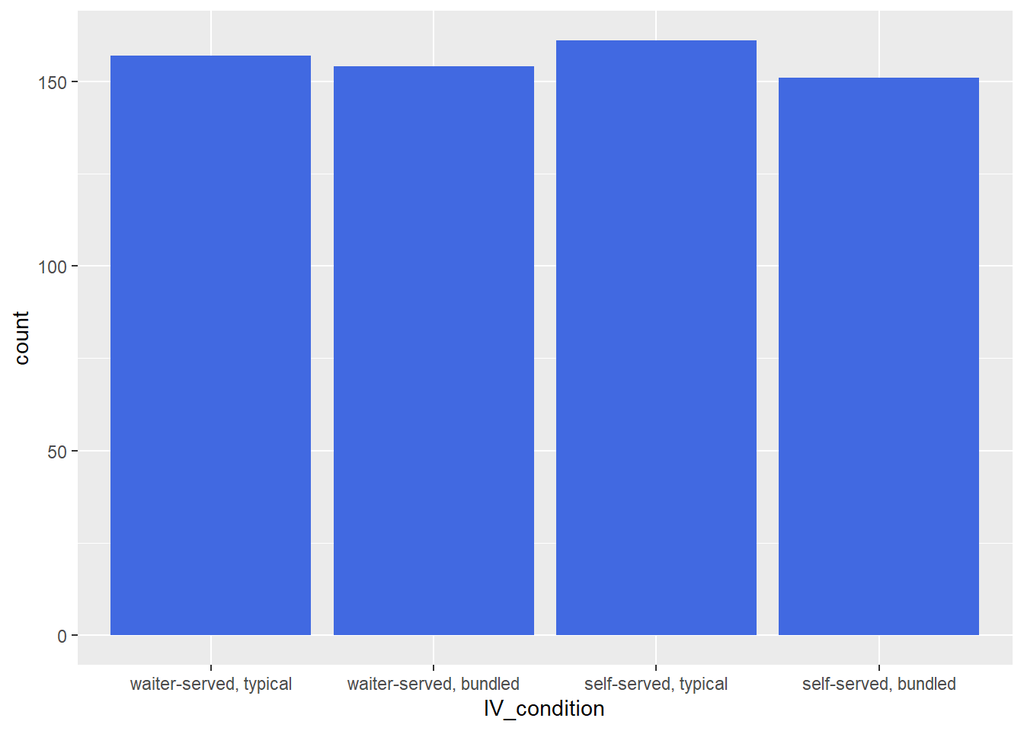

```r
ggplot(data = data_sugar,
       mapping = aes(x = IV_condition)) +
  geom_bar(fill = "royalblue")
```

### Two Categorical Variables

A clustered bar chart can be created by making some slight changes to the code for a single variable bar chart.

1. Add another aesthetic to the mapping argument in the `ggplot()` function.  
   * This tells the `ggplot()` function that we want to color the bars depending on the value of the variable *sex*.
2. Remove the *fill* color from the `geom_bar()` function.  
   * If we did not remove this arugment, it would override step and fill every bar with “royalblue”.
3. Add a position adjustment to `geom_bar()`  
   * This makes the bars be placed side-by-side.  
   * If you are curious, run this code without completing step 3. What happens?

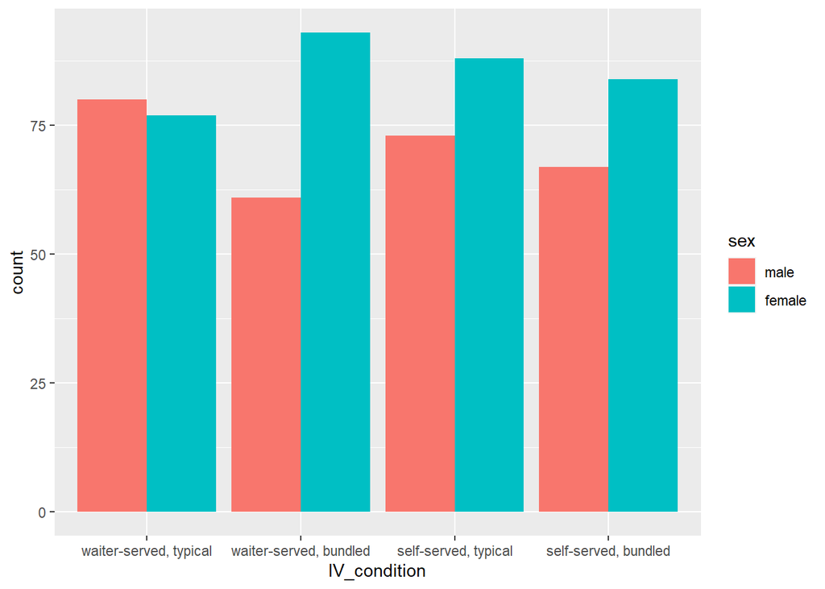

```r
ggplot(data = data_sugar,
       mapping = aes(x = IV_condition, fill = sex)) +
  geom_bar(position = position_dodge())
```

To learn more about Bar Charts, check out https://rstudio.cloud/learn/primers/3.2.

## Histogram

When you run the following code, you should see two warnings. Warnings are R’s way of trying to draw your attention to something. It is up to you to decide if it is a problem or not. The first warning is saying that by default the `geom_histogram()` function used 30 bins when creating the histogram for you. A histogram bin is like a container which counts how many data points from a single variable fall within a particular range (or binwidth). So, using 30 bins to create a histogram will take the full range of a variable and divide into 30 equally sized bins (all with the same binwidth). That could be too few bins or too many bins. You need to decide if you want to change the number of bins or change the binwidth. The second warning is trying to remind you that the *age* variable has 13 missing values, and as such the missing values could not be placed on the graph.

```
## Warning: Removed 13 rows containing non-finite values
## (stat_bin).
```

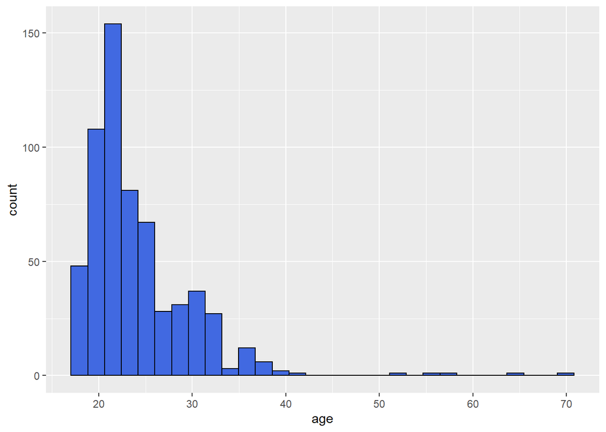

```r
ggplot(data = data_sugar,
       mapping = aes(x = age)) +
    geom_histogram(fill = "royalblue",
                   color = "black")
```

To learn more about histograms, check out https://rstudio.cloud/learn/primers/3.3.

## Box Plot

### One Continuous Variable

The following box plot shows the distribution *age* from our example data set. To recreate the graph below yourself, you need to try to solve the puzzle located in the section of this exercise which discusses the `mutate()` function, and then run the code below.

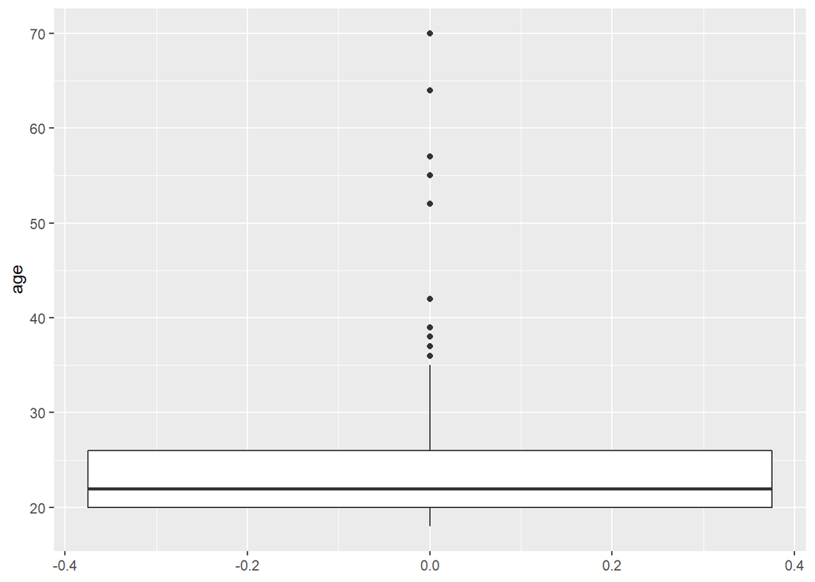

```r
ggplot(data = data_sugar,
       mapping = aes(y = age)) +
  geom_boxplot()
```

### One Continuous/One Catagorical

The following box plot shows the distributions of *age* broken down by each *IV_condition*. To recreate the graph below yourself, you need to try to solve the puzzle located in the section of this exercise which discusses the `mutate()` function, and then run the code below.

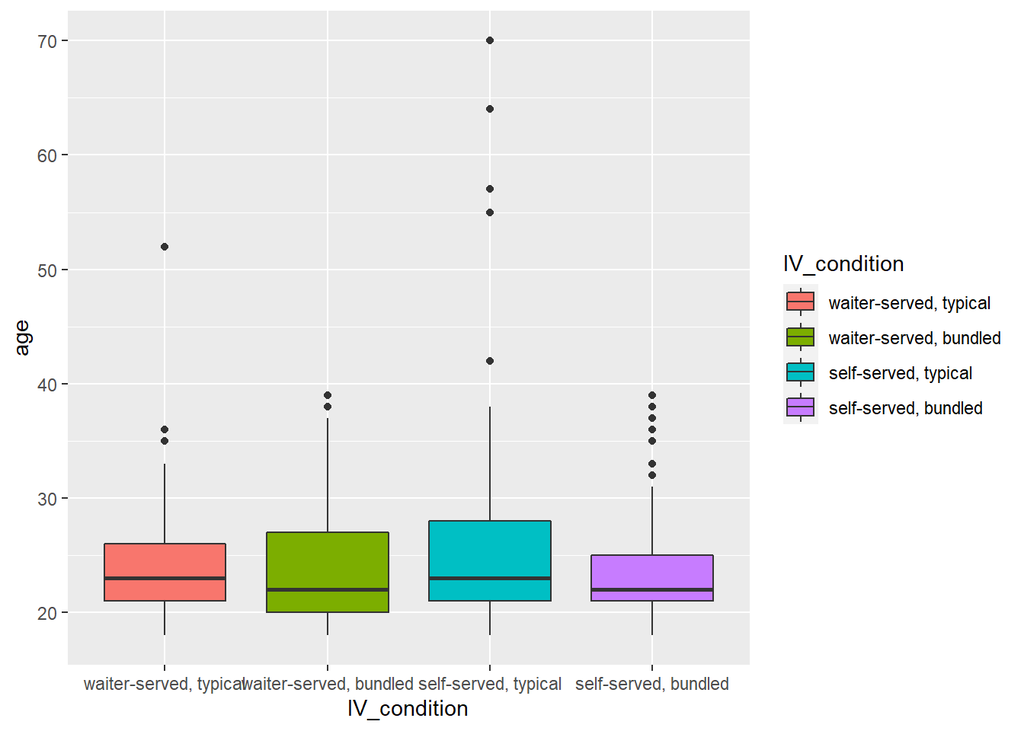

```r
ggplot(data = data_sugar,
       mapping = aes(x = IV_condition, y = age)) +
  geom_boxplot(aes(fill = IV_condition))
```

To learn more about box plots, check out https://rstudio.cloud/learn/primers/3.4.

# Acknowledgements

- The lovely “DIV TIPS” were made using code from a fantastic blog entry by Desirée de leon at https://desiree.rbind.io/post/2019/making-tip-boxes-with-bookdown-and-rmarkdown/
- The copy to clipboard buttons were created using Klippy https://rlesur.github.io/klippy/reference/klippy.html

This work is licensed under a [Creative Commons Attribution-NonCommercial 4.0 International License](http://creativecommons.org/licenses/by-nc/4.0/).